# SPOTIFY HITS ANALYSIS

## Introduction

I have two datasets, one is 2019 top US 200 songs by day, the other one is the top 200 song's features of 2019. The objective is to see if there are clusters of the top hits based on their features and if in one of those clusters the top streamed songs are placed.

## Libraries

Pandas\ Numpy\ Matplotlib\ Seaborn\ Plotly\ Cufflinks\ Sklearn KMeans

```python
import pandas as pd

import numpy as np

import matplotlib.pyplot as plt
%matplotlib inline

import seaborn as sns

import chart_studio.plotly as py
from plotly import __version__
from plotly.offline import download_plotlyjs, init_notebook_mode, plot, iplot
import plotly.graph_objects as go
import plotly.express as px
print(__version__)

import cufflinks as cf
# For Notebooks
init_notebook_mode(connected=True)
# For offline use
cf.go_offline()

pd.set_option('display.float_format', lambda x: '%.5f' % x)
```

```
4.8.0
```

## Datasets

```python
streams = pd.read_csv('1Top200us2019id.csv')
songs=pd.read_csv('1SpotifySongsFeatures2019.csv')
```

### Streams dataset

```python
streams.head()
```

|  | Rank | Track | Artist | Streams | Date | id |
| --- | --- | --- | --- | --- | --- | --- |
| 0 | 1 | Sunflower - Spider-Man: Into the Spider-Verse | by Post Malone | 1,867,789 | 01/01/2019 | https://open.spotify.com/track/3KkXRkHbMCARz0a... |
| 1 | 2 | Wow. | by Post Malone | 1,564,946 | 01/01/2019 | https://open.spotify.com/track/6MWtB6iiXyIwun0... |
| 2 | 3 | SICKO MODE | by Travis Scott | 1,454,622 | 01/01/2019 | https://open.spotify.com/track/2xLMifQCjDGFmkH... |
| 3 | 4 | thank u, next | by Ariana Grande | 1,397,512 | 01/01/2019 | https://open.spotify.com/track/2rPE9A1vEgShuZx... |
| 4 | 5 | Going Bad (feat. Drake) | by Meek Mill | 1,245,437 | 01/01/2019 | https://open.spotify.com/track/2IRZnDFmlqMuOrY... |

### Songs dataset

```python
songs.head()
```

|  | Track | Artist | id | V1 | danceability | energy | key | loudness | mode | speechiness | ... | instrumentalness | liveness | valence | tempo | type | uri | track_href | analysis_url | duration_ms | time_signature |
| --- | --- | --- | --- | --- | --- | --- | --- | --- | --- | --- | --- | --- | --- | --- | --- | --- | --- | --- | --- | --- | --- |
| 0 | Sunflower - Spider-Man: Into the Spider-Verse | Post Malone | 3KkXRkHbMCARz0aVfEt68P | 275441659 | 0.76000 | 0.47900 | 2 | -5.57400 | 1 | 0.04660 | ... | 0.00000 | 0.07030 | 0.91300 | 89.91100 | audio_features | spotify:track:3KkXRkHbMCARz0aVfEt68P | https://api.spotify.com/v1/tracks/3KkXRkHbMCAR... | https://api.spotify.com/v1/audio-analysis/3KkX... | 158040 | 4 |
| 1 | Wow. | Post Malone | 6MWtB6iiXyIwun0YzU6DFP | 240255598 | 0.83300 | 0.53900 | 11 | -7.39900 | 0 | 0.17800 | ... | 0.00000 | 0.10100 | 0.38500 | 99.94700 | audio_features | spotify:track:6MWtB6iiXyIwun0YzU6DFP | https://api.spotify.com/v1/tracks/6MWtB6iiXyIw... | https://api.spotify.com/v1/audio-analysis/6MWt... | 149520 | 4 |
| 2 | SICKO MODE | Travis Scott | 2xLMifQCjDGFmkHkpNLD9h | 198222966 | 0.83400 | 0.73000 | 8 | -3.71400 | 1 | 0.22200 | ... | 0.00000 | 0.12400 | 0.44600 | 155.00800 | audio_features | spotify:track:2xLMifQCjDGFmkHkpNLD9h | https://api.spotify.com/v1/tracks/2xLMifQCjDGF... | https://api.spotify.com/v1/audio-analysis/2xLM... | 312820 | 4 |
| 3 | thank u, next | Ariana Grande | 2rPE9A1vEgShuZxxzR2tZH | 41211441 | 0.72400 | 0.64700 | 1 | -5.64200 | 1 | 0.06580 | ... | 0.00000 | 0.10200 | 0.43500 | 106.96000 | audio_features | spotify:track:2rPE9A1vEgShuZxxzR2tZH | https://api.spotify.com/v1/tracks/2rPE9A1vEgSh... | https://api.spotify.com/v1/audio-analysis/2rPE... | 207333 | 4 |
| 4 | Going Bad (feat. Drake) | Meek Mill | 2IRZnDFmlqMuOrYOLnZZyc | 242595435 | 0.88900 | 0.49600 | 4 | -6.36500 | 0 | 0.09050 | ... | 0.00000 | 0.25200 | 0.54400 | 86.00300 | audio_features | spotify:track:2IRZnDFmlqMuOrYOLnZZyc | https://api.spotify.com/v1/tracks/2IRZnDFmlqMu... | https://api.spotify.com/v1/audio-analysis/2IRZ... | 180522 | 4 |

5 rows × 21 columns

## EDA Streams

```python
streams.info()
```

```
<class 'pandas.core.frame.DataFrame'>
RangeIndex: 72800 entries, 0 to 72799
Data columns (total 6 columns):
Rank       72800 non-null int64
Track      72800 non-null object
Artist     72800 non-null object
Streams    72800 non-null object
Date       72800 non-null object
id         72800 non-null object
dtypes: int64(1), object(5)
memory usage: 3.3+ MB
```

### Observations

In Streams: \ Delete "by" in Artist \ Streams has to be numeric \ Date has to be date \ Delete the url in id

```python
streams['Artist']=streams['Artist'].str[3:]

streams['Streams']= streams['Streams'].str.replace(',', '')
streams['Streams']= pd.to_numeric(streams['Streams'], errors='coerce')

streams['Date']= pd.to_datetime(streams['Date'])

streams['id']= streams['id'].str.replace('https://open.spotify.com/track/', '')
```

```python
streams.head()
```

|  | Rank | Track | Artist | Streams | Date | id |
| --- | --- | --- | --- | --- | --- | --- |
| 0 | 1 | Sunflower - Spider-Man: Into the Spider-Verse | Post Malone | 1867789 | 2019-01-01 | 3KkXRkHbMCARz0aVfEt68P |
| 1 | 2 | Wow. | Post Malone | 1564946 | 2019-01-01 | 6MWtB6iiXyIwun0YzU6DFP |
| 2 | 3 | SICKO MODE | Travis Scott | 1454622 | 2019-01-01 | 2xLMifQCjDGFmkHkpNLD9h |
| 3 | 4 | thank u, next | Ariana Grande | 1397512 | 2019-01-01 | 2rPE9A1vEgShuZxxzR2tZH |
| 4 | 5 | Going Bad (feat. Drake) | Meek Mill | 1245437 | 2019-01-01 | 2IRZnDFmlqMuOrYOLnZZyc |

```python
streams.info()
```

```
<class 'pandas.core.frame.DataFrame'>
RangeIndex: 72800 entries, 0 to 72799
Data columns (total 6 columns):
Rank       72800 non-null int64
Track      72800 non-null object
Artist     72800 non-null object
Streams    72800 non-null int64
Date       72800 non-null datetime64[ns]
id         72800 non-null object
dtypes: datetime64[ns](1), int64(2), object(3)
memory usage: 3.3+ MB
```

### Create a dataset of total streams per song

```python
totalstreams=streams.copy()
totalstreams.drop(['Rank','Track','Artist','Date'], axis=1,inplace=True)
tsid=totalstreams.groupby('id').sum()
tsid.sort_values('Streams',ascending=False,inplace=True)
```

```python
tsid.head()
```

| id | Streams |
| --- | --- |
| 2JvzF1RMd7lE3KmFlsyZD8 | 277363026 |
| 3KkXRkHbMCARz0aVfEt68P | 275441659 |
| 2Fxmhks0bxGSBdJ92vM42m | 266302864 |
| 2IRZnDFmlqMuOrYOLnZZyc | 242595435 |
| 6MWtB6iiXyIwun0YzU6DFP | 240255598 |

## EDA Songs

```python
songs.info()
```

```
<class 'pandas.core.frame.DataFrame'>
RangeIndex: 2066 entries, 0 to 2065
Data columns (total 21 columns):
Track               2066 non-null object
Artist              2066 non-null object
id                  2066 non-null object
V1                  2066 non-null int64
danceability        2066 non-null float64
energy              2066 non-null float64
key                 2066 non-null int64
loudness            2066 non-null float64
mode                2066 non-null int64
speechiness         2066 non-null float64
acousticness        2066 non-null float64
instrumentalness    2066 non-null float64
liveness            2066 non-null float64
valence             2066 non-null float64
tempo               2066 non-null float64
type                2066 non-null object
uri                 2066 non-null object
track_href          2066 non-null object
analysis_url        2066 non-null object
duration_ms         2066 non-null int64
time_signature      2066 non-null int64
dtypes: float64(9), int64(5), object(7)
memory usage: 339.1+ KB
```

### Observations

In Songs:\ Delete unnecesary features\ (V1, type, uri, track_href, analysis_url) Create a dataset with only songs features

```python
songs.drop(['V1', 'type', 'uri', 'track_href', 'analysis_url'], axis=1, inplace=True)
```

```python
songs.describe()
```

|  | danceability | energy | key | loudness | mode | speechiness | acousticness | instrumentalness | liveness | valence | tempo | duration_ms | time_signature |
| --- | --- | --- | --- | --- | --- | --- | --- | --- | --- | --- | --- | --- | --- |
| count | 2066.00000 | 2066.00000 | 2066.00000 | 2066.00000 | 2066.00000 | 2066.00000 | 2066.00000 | 2066.00000 | 2066.00000 | 2066.00000 | 2066.00000 | 2066.00000 | 2066.00000 |
| mean | 0.67088 | 0.60499 | 5.20716 | -6.80369 | 0.61859 | 0.14254 | 0.25712 | 0.01684 | 0.17863 | 0.46569 | 121.84593 | 199715.72168 | 3.94385 |
| std | 0.15935 | 0.17519 | 3.65771 | 2.85925 | 0.48585 | 0.12751 | 0.26826 | 0.09699 | 0.13632 | 0.21625 | 30.69911 | 58175.02043 | 0.38588 |
| min | 0.14800 | 0.01370 | 0.00000 | -25.16600 | 0.00000 | 0.02290 | 0.00004 | 0.00000 | 0.02150 | 0.02620 | 46.71800 | 30301.00000 | 1.00000 |
| 25% | 0.56725 | 0.50200 | 1.00000 | -7.96425 | 0.00000 | 0.04460 | 0.04235 | 0.00000 | 0.09970 | 0.29600 | 97.00500 | 167789.25000 | 4.00000 |
| 50% | 0.68700 | 0.62200 | 5.00000 | -6.25700 | 1.00000 | 0.08500 | 0.15300 | 0.00000 | 0.12400 | 0.46000 | 120.09400 | 194917.50000 | 4.00000 |
| 75% | 0.78600 | 0.72900 | 8.00000 | -4.93350 | 1.00000 | 0.21600 | 0.39700 | 0.00002 | 0.20400 | 0.62400 | 144.95625 | 222533.00000 | 4.00000 |
| max | 0.97800 | 0.97800 | 11.00000 | -1.33900 | 1.00000 | 0.93300 | 0.99400 | 0.95600 | 0.96300 | 0.98200 | 232.69000 | 943529.00000 | 5.00000 |

```python
songs.columns
```

```
Index(['Track', 'Artist', 'id', 'danceability', 'energy', 'key', 'loudness',
       'mode', 'speechiness', 'acousticness', 'instrumentalness', 'liveness',
       'valence', 'tempo', 'duration_ms', 'time_signature'],
      dtype='object')
```

```python
songs_ft=songs[['danceability', 'energy', 'key', 'loudness',
       'mode', 'speechiness', 'acousticness', 'instrumentalness', 'liveness',
       'valence', 'tempo', 'duration_ms', 'time_signature']]
```

```python
songs_ft.head()
```

|  | danceability | energy | key | loudness | mode | speechiness | acousticness | instrumentalness | liveness | valence | tempo | duration_ms | time_signature |
| --- | --- | --- | --- | --- | --- | --- | --- | --- | --- | --- | --- | --- | --- |
| 0 | 0.76000 | 0.47900 | 2 | -5.57400 | 1 | 0.04660 | 0.55600 | 0.00000 | 0.07030 | 0.91300 | 89.91100 | 158040 | 4 |
| 1 | 0.83300 | 0.53900 | 11 | -7.39900 | 0 | 0.17800 | 0.16300 | 0.00000 | 0.10100 | 0.38500 | 99.94700 | 149520 | 4 |
| 2 | 0.83400 | 0.73000 | 8 | -3.71400 | 1 | 0.22200 | 0.00513 | 0.00000 | 0.12400 | 0.44600 | 155.00800 | 312820 | 4 |
| 3 | 0.72400 | 0.64700 | 1 | -5.64200 | 1 | 0.06580 | 0.28000 | 0.00000 | 0.10200 | 0.43500 | 106.96000 | 207333 | 4 |
| 4 | 0.88900 | 0.49600 | 4 | -6.36500 | 0 | 0.09050 | 0.25900 | 0.00000 | 0.25200 | 0.54400 | 86.00300 | 180522 | 4 |

```python
from sklearn.preprocessing import StandardScaler, MinMaxScaler
```

```python
scaler = StandardScaler()
scaler.fit(songs_ft)
scaled_songs_ft = scaler.transform(songs_ft)
songs_ft_scl = pd.DataFrame(scaled_songs_ft,columns=songs_ft.columns)
songs_ft_scl.describe()
```

|  | danceability | energy | key | loudness | mode | speechiness | acousticness | instrumentalness | liveness | valence | tempo | duration_ms | time_signature |
| --- | --- | --- | --- | --- | --- | --- | --- | --- | --- | --- | --- | --- | --- |
| count | 2066.00000 | 2066.00000 | 2066.00000 | 2066.00000 | 2066.00000 | 2066.00000 | 2066.00000 | 2066.00000 | 2066.00000 | 2066.00000 | 2066.00000 | 2066.00000 | 2066.00000 |
| mean | -0.00000 | -0.00000 | 0.00000 | -0.00000 | -0.00000 | 0.00000 | -0.00000 | -0.00000 | 0.00000 | -0.00000 | 0.00000 | -0.00000 | 0.00000 |
| std | 1.00024 | 1.00024 | 1.00024 | 1.00024 | 1.00024 | 1.00024 | 1.00024 | 1.00024 | 1.00024 | 1.00024 | 1.00024 | 1.00024 | 1.00024 |
| min | -3.28202 | -3.37604 | -1.42396 | -6.42363 | -1.27351 | -0.93855 | -0.95857 | -0.17364 | -1.15293 | -2.03287 | -2.44783 | -2.91286 | -7.63076 |
| 25% | -0.65044 | -0.58804 | -1.15050 | -0.40600 | -1.27351 | -0.76832 | -0.80080 | -0.17364 | -0.57913 | -0.78491 | -0.80937 | -0.54893 | 0.14554 |
| 50% | 0.10121 | 0.09711 | -0.05665 | 0.19125 | 0.78523 | -0.45139 | -0.38824 | -0.17364 | -0.40083 | -0.02633 | -0.05708 | -0.08250 | 0.14554 |
| 75% | 0.72262 | 0.70804 | 0.76373 | 0.65424 | 0.78523 | 0.57626 | 0.52154 | -0.17345 | 0.18618 | 0.73225 | 0.75298 | 0.39231 | 0.14554 |
| max | 1.92778 | 2.12974 | 1.58412 | 1.91170 | 0.78523 | 6.20092 | 2.74750 | 9.68531 | 5.75540 | 2.38818 | 3.61154 | 12.78888 | 2.73764 |

```python
mmscaler = MinMaxScaler(feature_range=(-1, 1))
mmscaler.fit(songs_ft_scl)
mmscaled_songs_ft = mmscaler.transform(songs_ft_scl)
songs_ft_mmscl = pd.DataFrame(mmscaled_songs_ft,columns=songs_ft.columns)
```

### Standardrized and Scaled songs features

```python
songs_ft_mmscl.describe()
```

|  | danceability | energy | key | loudness | mode | speechiness | acousticness | instrumentalness | liveness | valence | tempo | duration_ms | time_signature |
| --- | --- | --- | --- | --- | --- | --- | --- | --- | --- | --- | --- | --- | --- |
| count | 2066.00000 | 2066.00000 | 2066.00000 | 2066.00000 | 2066.00000 | 2066.00000 | 2066.00000 | 2066.00000 | 2066.00000 | 2066.00000 | 2066.00000 | 2066.00000 | 2066.00000 |
| mean | 0.25994 | 0.22636 | -0.05324 | 0.54130 | 0.23717 | -0.73708 | -0.48270 | -0.96477 | -0.66622 | -0.08037 | -0.19205 | -0.62898 | 0.47193 |
| std | 0.38399 | 0.36334 | 0.66504 | 0.24000 | 0.97170 | 0.28020 | 0.53979 | 0.20291 | 0.28958 | 0.45249 | 0.33015 | 0.12741 | 0.19294 |
| min | -1.00000 | -1.00000 | -1.00000 | -1.00000 | -1.00000 | -1.00000 | -1.00000 | -1.00000 | -1.00000 | -1.00000 | -1.00000 | -1.00000 | -1.00000 |
| 25% | 0.01024 | 0.01276 | -0.81818 | 0.44389 | -1.00000 | -0.95231 | -0.91486 | -1.00000 | -0.83388 | -0.43545 | -0.45920 | -0.69890 | 0.50000 |
| 50% | 0.29880 | 0.26164 | -0.09091 | 0.58719 | 1.00000 | -0.86353 | -0.69222 | -1.00000 | -0.78226 | -0.09228 | -0.21089 | -0.63948 | 0.50000 |
| 75% | 0.53735 | 0.48356 | 0.45455 | 0.69828 | 1.00000 | -0.57565 | -0.20125 | -0.99996 | -0.61232 | 0.25089 | 0.05648 | -0.57901 | 0.50000 |
| max | 1.00000 | 1.00000 | 1.00000 | 1.00000 | 1.00000 | 1.00000 | 1.00000 | 1.00000 | 1.00000 | 1.00000 | 1.00000 | 1.00000 | 1.00000 |

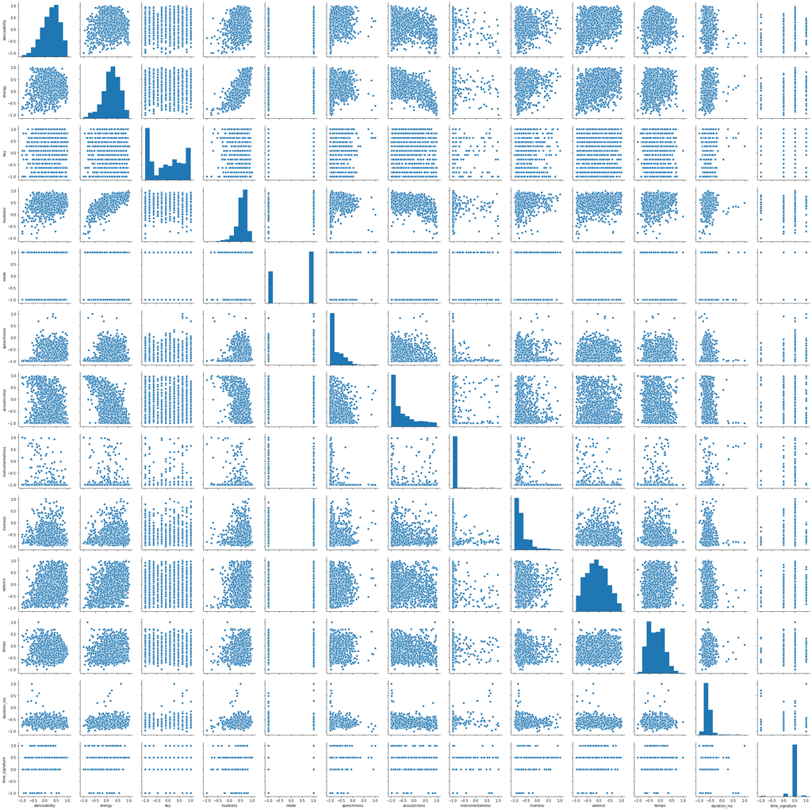

```python
sns.pairplot(songs_ft_mmscl)
```

[output not shown]

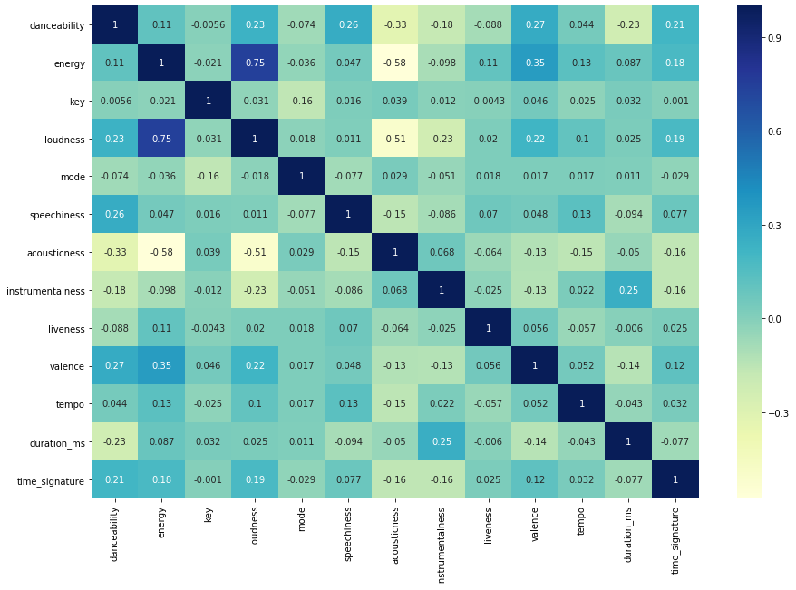

```python
fig, ax = plt.subplots(figsize=(15,10))
sns.heatmap(songs_ft_mmscl.corr(),annot=True, ax=ax, cmap='YlGnBu')
bottom, top = ax.get_ylim()
ax.set_ylim(bottom + 0.5, top - 0.5)
```

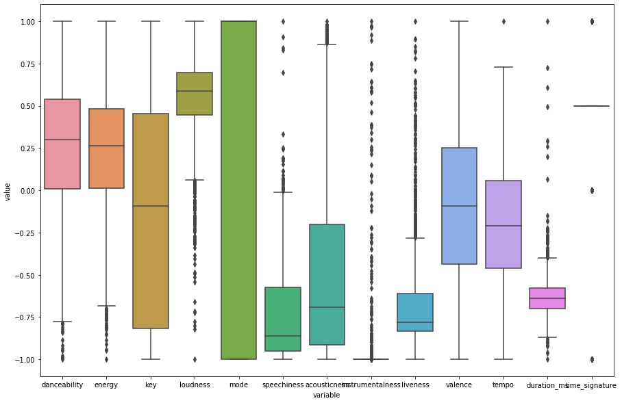

```python
fig, ax = plt.subplots(figsize=(15,10))
plot_songs_ft_mmscl=pd.melt(songs_ft_mmscl)
sns.boxplot(x='variable',y='value',data = plot_songs_ft_mmscl)
```

```python
songs_ft_mmscl.columns
```

```
Index(['danceability', 'energy', 'key', 'loudness', 'mode', 'speechiness',
       'acousticness', 'instrumentalness', 'liveness', 'valence', 'tempo',
       'duration_ms', 'time_signature'],
      dtype='object')
```

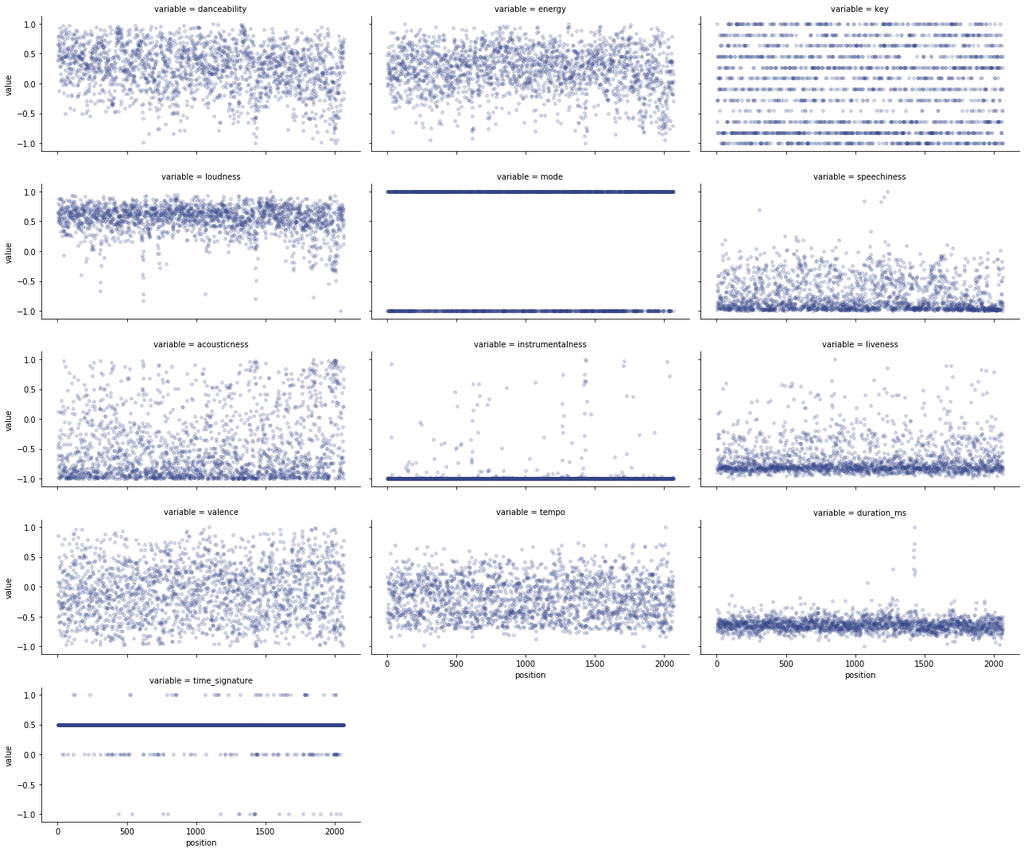

```python
plot2_songs_ft_mmscl=songs_ft_mmscl.copy()
plot2_songs_ft_mmscl['position'] = plot2_songs_ft_mmscl.index +1
plot2_songs_ft_mmscl= pd.melt(plot2_songs_ft_mmscl,id_vars=['position'])
g=sns.FacetGrid(plot2_songs_ft_mmscl,col='variable',col_wrap=3, aspect=2)
g=g.map(plt.scatter,'position', 'value',color = "#334488", alpha=0.2,s=15)
```

## Cluster K-means

```python
from sklearn.cluster import KMeans
```

### Choose number of clusters

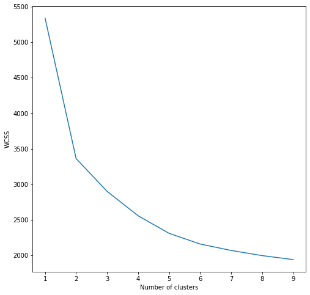

```python
wcss =[]
for i in range(1,10):
    kmeanss = KMeans(i)
    kmeanss.fit(songs_ft_mmscl)
    wcss.append(kmeanss.inertia_)
fig, ax = plt.subplots(figsize=(8,8))
elbow=plt.plot(range(1,10),wcss)
plt.xlabel('Number of clusters')
plt.ylabel('WCSS')
```

```python
np.random.seed(123)
kmeans = KMeans(n_clusters=5,random_state=123)
kmeans.fit(songs_ft_mmscl)
```

```
KMeans(n_clusters=5, random_state=123)
```

```python
np.random.seed(123)
clusters=songs_ft_mmscl.copy()
clusters['clusters']=kmeans.fit_predict(songs_ft_mmscl)
```

```python
clusters.head()
```

|  | danceability | energy | key | loudness | mode | speechiness | acousticness | instrumentalness | liveness | valence | tempo | duration_ms | time_signature | clusters |
| --- | --- | --- | --- | --- | --- | --- | --- | --- | --- | --- | --- | --- | --- | --- |
| 0 | 0.47470 | -0.03495 | -0.63636 | 0.64452 | 1.00000 | -0.94792 | 0.11868 | -1.00000 | -0.89634 | 0.85562 | -0.53549 | -0.72025 | 0.50000 | 4 |
| 1 | 0.65060 | 0.08949 | 1.00000 | 0.49133 | -1.00000 | -0.65916 | -0.67210 | -1.00000 | -0.83112 | -0.24922 | -0.42756 | -0.73891 | 0.50000 | 1 |
| 2 | 0.65301 | 0.48564 | 0.45455 | 0.80065 | 1.00000 | -0.56247 | -0.98975 | -1.00000 | -0.78226 | -0.12157 | 0.16458 | -0.38127 | 0.50000 | 0 |
| 3 | 0.38795 | 0.31349 | -0.81818 | 0.63881 | 1.00000 | -0.90572 | -0.43667 | -1.00000 | -0.82900 | -0.14459 | -0.35214 | -0.61229 | 0.50000 | 4 |
| 4 | 0.78554 | 0.00031 | -0.27273 | 0.57813 | -1.00000 | -0.85144 | -0.47893 | -1.00000 | -0.51036 | 0.08349 | -0.57752 | -0.67101 | 0.50000 | 2 |

```python
cluster_centers = pd.DataFrame(kmeans.cluster_centers_,columns=songs_ft_mmscl.columns)
cluster_centers['clusters']=cluster_centers.index+1
```

```python
cluster_centers
```

|  | danceability | energy | key | loudness | mode | speechiness | acousticness | instrumentalness | liveness | valence | tempo | duration_ms | time_signature | clusters |
| --- | --- | --- | --- | --- | --- | --- | --- | --- | --- | --- | --- | --- | --- | --- |
| 0 | 0.29330 | 0.31030 | 0.45282 | 0.59000 | 1.00000 | -0.73773 | -0.65957 | -0.97968 | -0.64476 | 0.00942 | -0.18913 | -0.62112 | 0.48864 | 1 |
| 1 | 0.31611 | 0.26650 | 0.63914 | 0.55701 | -1.00000 | -0.69492 | -0.54838 | -0.96401 | -0.65833 | -0.02329 | -0.18477 | -0.62012 | 0.48219 | 2 |
| 2 | 0.28653 | 0.22991 | -0.47547 | 0.54813 | -1.00000 | -0.72167 | -0.47017 | -0.94677 | -0.68693 | -0.14891 | -0.21181 | -0.63977 | 0.47954 | 3 |
| 3 | -0.10335 | -0.31222 | -0.06482 | 0.23046 | 0.96522 | -0.87034 | 0.50930 | -0.93390 | -0.71854 | -0.31213 | -0.28007 | -0.63838 | 0.38478 | 4 |
| 4 | 0.32382 | 0.34545 | -0.76232 | 0.61180 | 1.00000 | -0.72105 | -0.70001 | -0.97732 | -0.65535 | -0.06078 | -0.14708 | -0.63135 | 0.47996 | 5 |

```python
cluster_centers.dtypes
```

```
danceability        float64
energy              float64
key                 float64
loudness            float64
mode                float64
speechiness         float64
acousticness        float64
instrumentalness    float64
liveness            float64
valence             float64
tempo               float64
duration_ms         float64
time_signature      float64
clusters              int64
dtype: object
```

```python
plot_cluster_centers= pd.melt(cluster_centers,id_vars=['clusters'])
```

```python
px.line(plot_cluster_centers,'variable','value', color='clusters')
```

[interactive chart not shown]

```python
px.line_polar(data_frame=plot_cluster_centers,r='value',theta='variable',color='clusters',
              line_close=True,range_r=[-1.5,1])
```

[interactive chart not shown]

```python
fig=go.Figure()
x1='danceability'
y1='energy'
fig.add_trace(go.Scatter(x=clusters[clusters['clusters']==0][x1], y=clusters[clusters['clusters']==0][y1],
                    mode='markers',name='cluster 1',marker=dict(color="#636EFA")))
fig.add_trace(go.Scatter(x=clusters[clusters['clusters']==1][x1], y=clusters[clusters['clusters']==1][y1],
                    mode='markers',name='cluster 2',marker=dict(color="#EF553B")))
fig.add_trace(go.Scatter(x=clusters[clusters['clusters']==2][x1], y=clusters[clusters['clusters']==2][y1],
                    mode='markers',name='cluster 3',marker=dict(color="#00CC96")))
fig.add_trace(go.Scatter(x=clusters[clusters['clusters']==3][x1], y=clusters[clusters['clusters']==3][y1],
                    mode='markers',name='cluster 4',marker=dict(color="#AB63FA")))
fig.add_trace(go.Scatter(x=clusters[clusters['clusters']==4][x1], y=clusters[clusters['clusters']==4][y1],
                    mode='markers',name='cluster 5',marker=dict(color="#FFA15A")))
```

[interactive chart not shown]

## Join Songs with clusters & Total Streams per song

```python
songs1=songs_ft_mmscl.copy()
songs1['clusters']=kmeans.fit_predict(songs_ft_mmscl)
songs1['id']=songs['id']
songs1['clusters']=songs1['clusters']+1
```

```python
df=pd.merge(tsid,songs1,how='left', on='id')
```

```python
df.head()
```

|  | id | Streams | danceability | energy | key | loudness | mode | speechiness | acousticness | instrumentalness | liveness | valence | tempo | duration_ms | time_signature | clusters |
| --- | --- | --- | --- | --- | --- | --- | --- | --- | --- | --- | --- | --- | --- | --- | --- | --- |
| 0 | 2JvzF1RMd7lE3KmFlsyZD8 | 277363026 | 0.66024 | -0.27346 | 0.45455 | 0.12922 | 1.00000 | -0.44380 | -0.70027 | -1.00000 | -0.46999 | -0.08600 | -0.16906 | -0.59858 | 0.50000 | 1 |
| 1 | 3KkXRkHbMCARz0aVfEt68P | 275441659 | 0.47470 | -0.03495 | -0.63636 | 0.64452 | 1.00000 | -0.94792 | 0.11868 | -1.00000 | -0.89634 | 0.85562 | -0.53549 | -0.72025 | 0.50000 | 5 |
| 2 | 2Fxmhks0bxGSBdJ92vM42m | 266302864 | 0.33253 | -0.14695 | 0.27273 | 0.19201 | 1.00000 | -0.22624 | -0.34009 | -0.72803 | -0.83324 | 0.12116 | -0.04921 | -0.64130 | 0.50000 | 1 |
| 3 | 2IRZnDFmlqMuOrYOLnZZyc | 242595435 | 0.78554 | 0.00031 | -0.27273 | 0.57813 | -1.00000 | -0.85144 | -0.47893 | -1.00000 | -0.51036 | 0.08349 | -0.57752 | -0.67101 | 0.50000 | 3 |
| 4 | 6MWtB6iiXyIwun0YzU6DFP | 240255598 | 0.65060 | 0.08949 | 1.00000 | 0.49133 | -1.00000 | -0.65916 | -0.67210 | -1.00000 | -0.83112 | -0.24922 | -0.42756 | -0.73891 | 0.50000 | 2 |

```python
plot_df=df.copy()
plot_df=df.drop(['id','Streams'],axis=1)
plot_df['idn']=df.index+1
plot_df=pd.melt(plot_df,id_vars=['idn','clusters'])
```

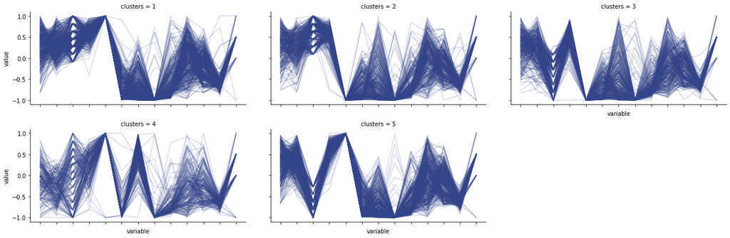

```python
g=sns.FacetGrid(plot_df,col='clusters',col_wrap=3, hue='idn',aspect=2)
g.map(sns.lineplot,'variable', 'value',color = "#334488" ,alpha=0.2,sort=False)
g.set_xticklabels(rotation=30)
```

```python
plot3_df=df.groupby('clusters').count().reset_index()
px.bar(plot3_df,x='clusters',y='Streams')
```

[interactive chart not shown]

```python
plot2_df=df.groupby('clusters').sum().reset_index()
px.bar(plot2_df,x='clusters',y='Streams')
```

[interactive chart not shown]

```python
df2=df.copy()
songs3=songs[['id','Artist','Track']]
df2=pd.merge(df,songs3,'left',on='id')
```

```python
df3=df2.groupby('Artist').sum().reset_index().sort_values('Streams',ascending=False)
df3=df3.head(20)
px.bar(df3,x='Artist',y='Streams',color='Artist')
```

[interactive chart not shown]

```python
px.bar(df2,x='clusters',y='Streams',color='Artist',hover_data=['Track'])
```

[interactive chart not shown]

## Conclusions

After analysing all the clusters differences and cross visualize them with total streams per song and per artist, I can say that top selling artist try to mix their songs styles so they can reach all kind of fans's preferences in music features. Since streaming is the new way of selling music, music albums are now a mix of genres and styles, and also the term of music album is becoming obsolete, Labels are prefering singles releases than complete albums.